# Twitter Sentiment Analysis

## 🧭 Overview & Setup

This notebook walks you through on:

1. How to run a sentiment analysis on tweets using the VADER package
2. How to interpret the VADER scores
3. How to view top positive/negative tweets
4. How to visualize the compound scores distribution

### 📦 Install and load packages

Install `tidyverse` and `vader` if you do not have them in your R environment.

- `tidyverse` is a collection of R packages for data science
- `vader` (Valence Aware Dictionary and sEntiment Reasoner) is a rule-based sentiment analysis tool specifically attuned to social media text

```r
# uncomment and run the lines below if you need to install these packages
# install.packages("tidyverse")
# install.packages("vader")
```

Load packages.

```r
library(tidyverse)
library(vader)
```

### 📃 Read CSV file

```r
df_tweets = read_csv('lululemon-tweets.csv')
df_tweets %>% head()
```

| id | username | text |
| --- | --- | --- |
| 1.603435e+18 | demsRinsane | @GOPChairwoman YOU NEED TO RESIGN. Lululemon you smug bitch 🖕🏻🖕🏻🖕🏻🖕🏻🖕🏻🖕🏻🖕🏻🖕🏻🖕🏻🖕🏻🖕🏻 https://t.co/AIY8Pmywxe |
| 1.603434e+18 | sherbertkuma | i want the lululemon pink water bottle so bad LOL i've been eyeing it for a couple months now but also i have so many water bottles already hahha |
| 1.603433e+18 | aidaampie | Only thing I want for Christmas is lululemon 🤭 life without my employee discount is not it |
| 1.603433e+18 | marinarodich | Check out this listing I just added to my #Poshmark closet: Lululemon Groove Pant SHR Flare *Nulu Color-Red Merlot Size-12 NWT. https://t.co/HQuLFfJbQj #shopmycloset @poshmarkapp |
| 1.603433e+18 | poshcitystore | Check out this listing I just found on #Poshmark: Lululemon Base Pace High-Rise Running Tight 25" in Floral Electric. https://t.co/7DCkj9q7o9 #shopmycloset @poshmarkapp |
| 1.603432e+18 | marinarodich | Check out this listing I just added to my #Poshmark closet: Lululemon Groove Pant SHR Flare *Nulu Color-Red Merlot Size-12 NWT. https://t.co/7QjMkOyDeQ #shopmycloset @poshmarkapp |

Print out the number of rows.

```r
nrow(df_tweets)
```

```
## [1] 4516
```

## 🔮 Sentiment Analysis

### 📌 Sample usage

To analyze a piece of text using VADER, use the `get_vader()` function. Here is an example using one of the tweets.

- `compound` score is the “overall” score between -1 (most extreme negative) and +1 (most extreme positive).
- `pos`, `neg`, and `neu` are ratios for proportions of text that fall in each category. These should all add up to be 1.
- We are mainly interested in the compound score.

```r
get_vader("Got my BeautyBase merch I am happy I got the first batch 🥰")
```

```
##                                 word_scores
## "{0, 0, 0, 0, 0, 0, 2.7, 0, 0, 0, 0, 0, 0}"
##                                    compound
##                                     "0.572"
##                                         pos
##                                     "0.236"
##                                         neu
##                                     "0.764"
##                                         neg
##                                         "0"
##                                   but_count
##                                         "0"
```

### 🧮 Calculate scores for all tweets

Because we have a DataFrame (`tibble`) that contains tweet texts in the `text` column, we will need to run `get_vader()` on each row of the `text` column. We can do this by using the `lapply()` function.

The code below stores the VADER results to a list variable named `vscores`. Note that this may take a while (a few minutes) if you have thousands of tweets.

```r
vscores <- df_tweets$text %>% lapply(get_vader)
```

Extract compound score and positive/neutral/negative percentages into separate columns.

```r
df_tweets <- df_tweets %>% mutate(
  compound = vscores %>% sapply(function(v) { as.numeric(v["compound"]) }),
  pos = vscores %>% sapply(function(v) { as.numeric(v["pos"]) }),
  neu = vscores %>% sapply(function(v) { as.numeric(v["neu"]) }),
  neg = vscores %>% sapply(function(v) { as.numeric(v["neg"]) }),
)
df_tweets
```

| id | username | text | compound | pos | neu | neg |
| --- | --- | --- | --- | --- | --- | --- |
| 1.603435e+18 | demsRinsane | @GOPChairwoman YOU NEED TO RESIGN. Lululemon you smug bitch 🖕🏻🖕🏻🖕🏻🖕🏻🖕🏻🖕🏻🖕🏻🖕🏻🖕🏻🖕🏻🖕🏻 https://t.co/AIY8Pmywxe | -0.730 | 0.108 | 0.478 | 0.414 |
| 1.603434e+18 | sherbertkuma | i want the lululemon pink water bottle so bad LOL i've been eyeing it for a couple months now but also i have so many water bottles already hahha | 0.111 | 0.119 | 0.807 | 0.074 |
| 1.603433e+18 | aidaampie | Only thing I want for Christmas is lululemon 🤭 life without my employee discount is not it | 0.077 | 0.075 | 0.925 | 0.000 |
| 1.603433e+18 | marinarodich | Check out this listing I just added to my #Poshmark closet: Lululemon Groove Pant SHR Flare *Nulu Color-Red Merlot Size-12 NWT. https://t.co/HQuLFfJbQj #shopmycloset @poshmarkapp | 0.000 | 0.000 | 1.000 | 0.000 |
| 1.603433e+18 | poshcitystore | Check out this listing I just found on #Poshmark: Lululemon Base Pace High-Rise Running Tight 25" in Floral Electric. https://t.co/7DCkj9q7o9 #shopmycloset @poshmarkapp | 0.000 | 0.000 | 1.000 | 0.000 |
| 1.603432e+18 | marinarodich | Check out this listing I just added to my #Poshmark closet: Lululemon Groove Pant SHR Flare *Nulu Color-Red Merlot Size-12 NWT. https://t.co/7QjMkOyDeQ #shopmycloset @poshmarkapp | 0.000 | 0.000 | 1.000 | 0.000 |
| 1.603431e+18 | Noosiekins | @cat1087 @lululemon it's been 4 days since I placed the order... just waiting to see if @lululemon is going to cancel or actually complete and ship my order this time | -0.250 | 0.000 | 0.935 | 0.065 |
| 1.603431e+18 | TroiBear28 | Check out this listing I just added to my #Poshmark closet: Lululemon Iris Flower 17" Breezy Crop Size 6. https://t.co/0jk1I2kF52 #shopmycloset @poshmarkapp | 0.000 | 0.000 | 1.000 | 0.000 |
| 1.603431e+18 | JoeShmo32152716 | @johnfund @GroverNorquist the guy who is in charge of getting republicans elected, spent money foolishly and purposely self-sabotaged the candidates? Oh wait…. That was @GOPLeader @LeaderMcConnell @GO… | -0.421 | 0.000 | 0.938 | 0.062 |
| 1.603430e+18 | ClothingShoesA1 | NWT Lululemon Align Pant Size 6 Tidewater Teal 28" Second Release 2022 https://t.co/c0zGxiDDzO eBay https://t.co/F9el2scUZw | 0.000 | 0.000 | 1.000 | 0.000 |

[output cut: 4506 more lines]

### 👍 50 most positive tweets

```r
df_tweets %>%
  arrange(desc(compound)) %>%
  select(text, username, compound, pos, neu, neg) %>%
  head(50)
```

| text | username | compound | pos | neu | neg |
| --- | --- | --- | --- | --- | --- |
| @CrystalRunsFree @micmacmall @lululemon @ROOTS Super fun, Crystal! Never too old (age is just a number) to play/be playful and just have fun doing whatever activities you enjoy!😊 Happy to see that you… | GetAfterIt4U | 0.980 | 0.461 | 0.539 | 0.000 |
| 🚨 LULULEMON - NOW OPEN! 🚨\n\n@lululemon is here, and we’re living for it! Come check out their wide selection of high-quality athletic wear and gear. Their knowledgeable and friendly staff are on hand… | thepencentre | 0.968 | 0.355 | 0.645 | 0.000 |
| @desota @lululemon @Costco @Broadcom is taking over the blockchain, \nA cool token with 0% tax, 100%, presale is live, with an active dev, best community ever, we moon with winners, join the winning t… | kinggoffer14 | 0.964 | 0.356 | 0.644 | 0.000 |
| @eWhispers @autozone @Veru_Pharma @lululemon @DocuSign @MongoDB @SAICinc @DLHCorp @Chewy @SentinelOne @gitlab is taking over the blockchain, \nA cool token with 0% tax, 100%, presale is live, with an … | kinggoffer14 | 0.964 | 0.318 | 0.682 | 0.000 |
| @desota @netflix @lululemon @DocuSign is taking over the blockchain, \nA cool token with 0% tax, 100%, presale is live, with an active dev, best community ever, we moon with winners, join the winning … | kinggoffer14 | 0.964 | 0.339 | 0.661 | 0.000 |
| @calvinmcdonald @lululemon Hello Mr Mcdonald. Love your products! Wow! Question. My wife looks so good in the leggings you make… i figure you owe me a commission on all the sales she causes. Lol. Merr… | Craig2325 | 0.962 | 0.375 | 0.625 | 0.000 |
| @SavLovesSwift I love aerie leggings mine are SO soft, but honestly lululemon, they are expensive but honestly everything I’ve gotten from there has been honestly worth the money IMO | maddieegrace1 | 0.960 | 0.433 | 0.567 | 0.000 |
| @Adriana1o5 We do that, same with PPC. We run ab 2M a year through them but what I am talking about are all the random benefits like free uber eats credits, 10% off lululemon, etc... all these benefit… | michaelpatron0 | 0.959 | 0.302 | 0.698 | 0.000 |
| @Amwysoc It is a great mall . My fav too ... live 15 minutes from it . But 2 joggers at Lululemon ... $275.00 ! My 19 year old is lucky I love him ! Ha ! | cboz__13 | 0.959 | 0.362 | 0.638 | 0.000 |
| OMG I love LOVE Lululemon! Please don’t tell me it’s going out of business. Ladies, they sell thee best leggings! https://t.co/ctvQsq43wr | CarrissaRent | 0.953 | 0.488 | 0.512 | 0.000 |

[output cut: 40 more lines]

### 👎 50 most negative tweets

```r
df_tweets %>%
  arrange(compound) %>%
  select(text, username, compound, pos, neu, neg) %>%
  head(50)
```

| text | username | compound | pos | neu | neg |
| --- | --- | --- | --- | --- | --- |
| You are a thief, Ronna! You are stealing American’s money to buy Lululemon? In case no one has told you, you are way too fat to wear that brand. Again, stealing and wasting our money. RESIGN. https://… | _Ms_Angela | -0.959 | 0.000 | 0.618 | 0.382 |
| Just had the worst experience with @lululemon Such a big company but totally ignores their customers and takes no responsibility for their errors. So disappointed 😞 #lululemon #lululemoncanada | beateq89 | -0.944 | 0.000 | 0.588 | 0.412 |
| This crime is insane and terrifying… tune in to hear Destiney delve into the Lululemon murder. \n\nSpotify: \n\nhttps://t.co/nnDTfZtb32\n\nAmazon Music:\n\nhttps://t.co/FVHl2w8PBO\n\nApple Podcast:\n\… | Salttheroom | -0.931 | 0.047 | 0.551 | 0.402 |
| @lululemon and @LaserShip shipments to Miami are definitely being stolen. Check the google reviews. Marked as delivered but not actually delivered. SEVERELY disappointed. I had a package worth over $2… | mellohealthgrp | -0.930 | 0.152 | 0.479 | 0.369 |
| @TuckerPeterson_ @KurtSchlichter @robbystarbuck @GOPChairwoman Aw, hell no. If I go so far as to support the RNC versus an individual candidate, and I have in the past, I'll be damned pissed to find o… | AnnykaV | -0.929 | 0.051 | 0.640 | 0.309 |
| @SquawkStreet @lululemon @calvinmcdonald @jimcramer U.S. to send $275 million in military aid to Ukraine; NATO chief worries war could become wider conflict\n\nBlood on your hands u war mongers | Bondking0071 | -0.917 | 0.000 | 0.660 | 0.340 |
| @rgkicks @HButter03 @ApeCrayonsYummy @unusual_whales Stop the cap with your faded ass under armpit shit just because you’re too poor to affor lululemon | ShitcoinSavant | -0.908 | 0.000 | 0.592 | 0.408 |
| @nationalpost @lululemon stuff is now sweat shop fast fashion crap AND they are appealing to a woke audience in ALL of their marketing rather than their actual consumer base. Fools fools fools | 1295QueenVic | -0.904 | 0.000 | 0.697 | 0.303 |
| It’s hard shopping from lululemon without thinking about the lululemon murders \U{01fae3} gotta stop with the true crime shit frfr | desafo_x | -0.898 | 0.089 | 0.444 | 0.467 |
| Does Lululemon's 12% Drop Signal Bad News For Clothing Retailers?\n\nLuxury athletic clothing retailer Lululemon gapped down 12%, after warning of higher-than-anticipated inventories. Is this a bad si… | indratno | -0.897 | 0.000 | 0.710 | 0.290 |

[output cut: 40 more lines]

### ⚖️ Average compound score

```r
mean(df_tweets$compound)
```

```
## [1] 0.1257358
```

### 📦 Box plot of compound scores

The box plot below gives you the spread and skewness of compound scores.

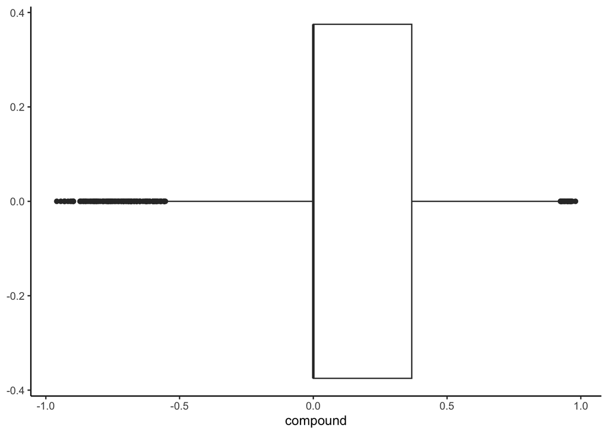

```r
df_tweets %>%
  ggplot(aes(x=compound)) +
  theme_classic() +
  geom_boxplot()
```

### 📊 Histogram of compound scores

The histogram below gives you an approximate distribution of the compound scores.

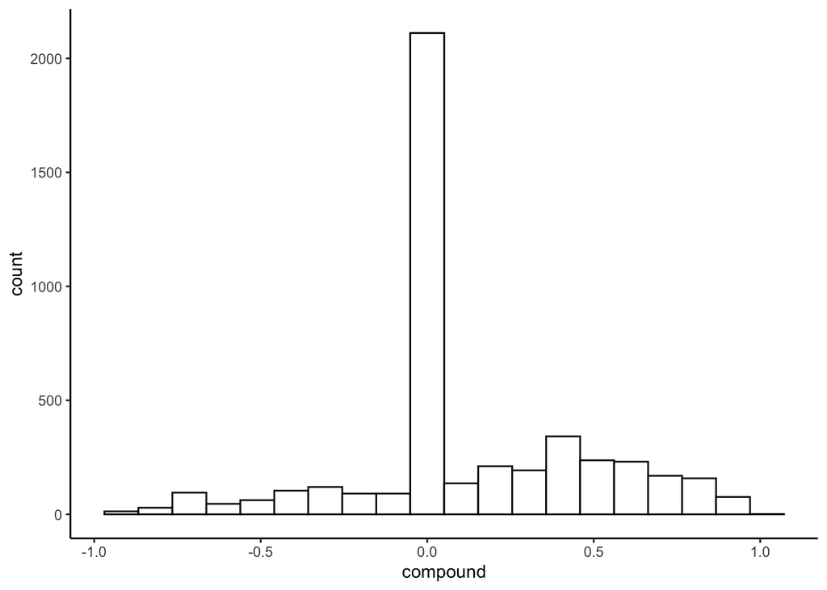

```r
df_tweets %>%
  ggplot(aes(x=compound)) +
  theme_classic() +
  geom_histogram(bins = 20, color="black", fill="white")
```